# TFM

Alessio Riccioli

10/9/2018

# Abstract

This study refers to an analysis, proposed by the Hospital Clínico San Carlos in Madrid, of the possibility of finding patterns of age, gender, and time period among patients admitted to the Emergency Department of the aforementioned hospital. For this work the following codes have been used: GRD, CDM and DCO that group and identify different types of diseases, transport, symptoms, intoxications, adverse effects of medications and any other reason why the patient should present at the consultation.

# Introducción

En el ambiente hospitalario, los códigos de diagnóstico se utilizan como una herramienta para agrupar e identificar enfermedades, trastornos, síntomas, envenenamientos, efectos adversos de drogas y productos químicos, lesiones y otras razones para el encuentro con el paciente. La codificación diagnóstica es la traducción de descripciones escritas de enfermedades, dolencias y lesiones en códigos de una clasificación particular. En la clasificación médica, los códigos de diagnóstico se utilizan como parte del proceso de codificación clínica junto con los códigos de intervención. Tanto los códigos de diagnóstico como los de intervención son asignados por un profesional de la salud capacitado en clasificación médica, como un codificador clínico o un administrador de información de salud. En este estudio se han utilizado sólo los códigos de diagnóstico. Se han implementado varios sistemas de clasificación de diagnósticos con diversos grados de éxito en todo el mundo. Las diversas clasificaciones se centran en un tipo particular de encuentro con el paciente, como emergencia, hospitalización, consulta externa, salud mental y atención quirúrgica. La International Statistical Classification of Diseases and Related Health Problems (ICD) es uno de los sistemas de clasificación más utilizados para la codificación de diagnósticos, ya que permite la comparabilidad y el uso de datos de mortalidad y morbilidad. De ahora en adelante nos referiremos a los ICD como DCO.

A medida que surgen los conocimientos sobre la salud y los avances médicos, los códigos de diagnóstico se revisan y actualizan para que coincidan con los conocimientos actuales más actualizados en el campo de la salud. Los códigos pueden revisarse con bastante frecuencia a medida que se adquieren nuevos conocimientos.

Los DCO son agrupados en GRD, o Grupos Relacionados por el Diagnóstico. Estos son una herramienta de gestión normalizadora,en la que mediante un programa informático, alimentado con los datos de los pacientes dados de alta hospitalaria el Conjunto Mínimo Básico de Datos (CMBD), podemos clasificar a los pacientes en grupos clínicamente similares y con parecido consumo de recursos sanitarios. CDM significa Categoría diagnóstica mayor. Los GRD son un sistema de clasificación de pacientes por sistema de ajustes de riesgos con base en el isoconsumo de recursos. Sirven para conocer la casuística de un hospital, el case mix hospitalario. Son muy útiles en la gestión y financiación de hospitales. Los GRD son un sistema de clasificación que clasifica a los pacientes hospitalarios en grupos homogéneos en cuanto al consumo de recursos.

Los GRD finalmente vienen a sus veces agrupados mediante los 26 CDM, o Categoría Diagnóstica Mayor. Las CDM se suelen ajustar a los grandes aparatos o sistemas corporales. Son las 26 siguientes:

- PreCDM (o CDM 0). Contiene una serie de GRD especiales.
- CDM 1. Enfermedades y trastornos del sistema nervioso.
- CDM 2. Enfermedades y trastornos del ojo.
- CDM 3. Enfermedades y trastornos del oído, nariz y boca.
- CDM 4. Enfermedades y trastornos del aparato respiratorio.
- CDM 5. Enfermedades y trastornos del aparato circulatorio.
- CDM 6. Enfermedades y trastornos del aparato digestivo.
- CDM 7. Enfermedades y trastornos del higado, sistema biliar y páncreas.
- CDM 8. Enfermedades y trastornos del sistema musculoesquelético y tejido conectivo.
- CDM 9. Enfermedades y trastornos de la piel, del tejido subcutáneo y de la mama.
- CDM 10. Enfermedades y trastornos endocrinos, nutricionales y metabólicos.
- CDM 11. Enfermedades y trastornos del riñón y vías urinarias.
- CDM 12. Enfermedades y trastornos del aparato reproductor masculino.
- CDM 13. Enfermedades y trastornos del aparato reproductor feminino.
- CDM 14. Embarazo, parto y puerperio.
- CDM 15. Recién nacidos y cuadros del periodo neonatal.
- CDM 16. Enfermedades y trastornos de sangre, sistema hematopoyético e inmunitario.
- CDM 17. Enfermedades y trastornos mieloproliferativos y neoplasias poco diferenciadas.
- CDM 18. Enfermedades infecciosas y parasitarias
- CDM 19. Enfermedades o trastornos mentales.
- CDM 20. Consumo alcohol/drogas y trastornos orgánicos mentales inducidos por drogas.
- CDM 21. Heridas, envenenamientos y efectos tóxicos de las drogas.
- CDM 22. Quemaduras.
- CDM 23. Factores que influyen en el estado de salud y otros contactos con servicios sanitarios.
- CDM 24. Infecciones por el Virus de la Inmunodeficiencia Humana.
- CDM 25. Politraumatismos importantes.

# Recopilación y preparación de datos

```r
rm(list=ls())
library(dplyr)
```

```r
library(magrittr)
DCO = read.csv("DCO.csv", header = FALSE)
GRD = read.csv("GRD.csv", header = FALSE)
patologia = read.csv("patologia.csv", header = FALSE)
servicios = read.csv("Servicios.csv", header = FALSE)
colnames(DCO) <- c("id","DCO", "Description")
colnames(GRD) <- c("id","GRD", "Description")
colnames(patologia) <- c("id","N_historia", "Gender", "Edad", "Fec_Serv", "S_ingreso", "S_alta", "GRD", "Severidad", "Version_Grd", "Cdm", "Peso_Grd", "DCO")
colnames(servicios) <- c("id", "serv", "description")
dim(DCO)
```

```
## [1] 3760    3
```

```r
dim(GRD)
```

```
## [1] 301   3
```

```r
dim(patologia)
```

```
## [1] 44151    13
```

```r
dim(servicios)
```

```
## [1] 35  3
```

```r
# Join entre los dataframes para trabajar con una sola tabla.
primermerge <- merge(patologia, GRD, by = "GRD", all = TRUE)
segundomerge <- merge(primermerge, DCO, by = "DCO", all = TRUE)
patologia_limpio <- subset(segundomerge, select = -c(id.x, N_historia, S_ingreso, S_alta, Version_Grd, Peso_Grd, id.y, id))
colnames(patologia_limpio)[colnames(patologia_limpio)=="Description.x"] <- "Descripcion_GRD"
colnames(patologia_limpio)[colnames(patologia_limpio)=="Description.y"] <- "Descripcion_DCO"
patologia_limpio[, 'DCO'] <- as.factor(patologia_limpio[, 'DCO'])
patologia_limpio[, 'GRD'] <- as.factor(patologia_limpio[, 'GRD'])
patologia_limpio[, 'Fec_Serv'] <- as.Date(patologia_limpio[, 'Fec_Serv'])
patologia_limpio[, 'Severidad'] <- as.factor(patologia_limpio[, 'Severidad'])
patologia_limpio[, 'Descripcion_GRD'] <- as.character(patologia_limpio[, 'Descripcion_GRD'])
patologia_limpio[, 'Descripcion_DCO'] <- as.character(patologia_limpio[, 'Descripcion_DCO'])
patologia_limpio[, 'Descripcion_DCO'] <- as.character(patologia_limpio[, 'Descripcion_DCO'])
patologia_limpio[, 'Cdm'] <- as.factor(patologia_limpio[, 'Cdm'])

str(patologia_limpio)  # Tipo de variables
```

```
## 'data.frame':    44151 obs. of  9 variables:
##  $ DCO            : Factor w/ 3760 levels "A02.0","A02.1",..: 1 1 1 1 1 1 1 1 1 1 ...
##  $ GRD            : Factor w/ 301 levels "3","4","5","20",..: 111 111 111 111 111 111 111 111 111 111 ...
##  $ Gender         : Factor w/ 2 levels "F","M": 1 1 2 2 1 2 1 2 1 1 ...
##  $ Edad           : int  35 36 77 35 22 23 72 59 79 51 ...
##  $ Fec_Serv       : Date, format: "2017-08-08" "2016-05-21" ...
##  $ Severidad      : Factor w/ 5 levels "0","1","2","3",..: 4 2 3 2 3 2 2 2 3 4 ...
##  $ Cdm            : Factor w/ 26 levels "0","1","2","3",..: 7 7 7 7 7 7 7 7 7 7 ...
##  $ Descripcion_GRD: chr  "INFECCIONES BACTERIANAS MAYORES DE APARATO DIGESTIVO" "INFECCIONES BACTERIANAS MAYORES DE APARATO DIGESTIVO" "INFECCIONES BACTERIANAS MAYORES DE APARATO DIGESTIVO" "INFECCIONES BACTERIANAS MAYORES DE APARATO DIGESTIVO" ...
##  $ Descripcion_DCO: chr  "Enteritis debida a Salmonella" "Enteritis debida a Salmonella" "Enteritis debida a Salmonella" "Enteritis debida a Salmonella" ...
```

```r
summary(patologia_limpio) # Resumen de las variables
```

```
##       DCO             GRD        Gender         Edad
##  I50.9  : 2004   560    : 2737   F:24027   Min.   :  0.00
##  N39.0  : 1513   194    : 2219   M:20124   1st Qu.: 44.00
##  J18.9  : 1502   139    : 1938             Median : 71.00
##  J22    : 1277   463    : 1801             Mean   : 63.26
##  O48.0  : 1153   144    : 1661             3rd Qu.: 84.00
##  O42.92 :  645   140    : 1304             Max.   :107.00
##  (Other):36057   (Other):32491
##     Fec_Serv          Severidad      Cdm        Descripcion_GRD
##  Min.   :1984-10-16   0:    9   4      : 7541   Length:44151
##  1st Qu.:2016-06-04   1:13637   5      : 6961   Class :character
##  Median :2016-12-06   2:18138   6      : 5642   Mode  :character
##  Mean   :2016-12-10   3:10804   14     : 4282
##  3rd Qu.:2017-06-12   4: 1563   11     : 3305
##  Max.   :2017-12-31             1      : 3302
##                                 (Other):13118
##  Descripcion_DCO
##  Length:44151
##  Class :character
##  Mode  :character
##
##
##
##
```

Se han juntado las diferentes tablas en *patologia_limpio* para que el análisis resulte más claro.

# Análisis de Frecuencias de las enfermedades

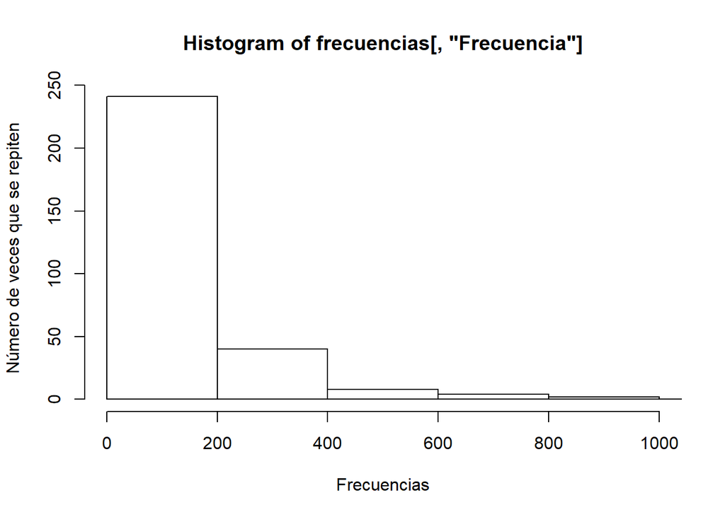

```r
frecuencias <- as.data.frame(table(patologia_limpio[, 'GRD']))
colnames(frecuencias) <- c("GRD","Frecuencia")
hist(frecuencias[, 'Frecuencia'], xlim=c(0,1000), xlab = "Frecuencias", ylab = "Número de veces que se repiten")
```

```r
table(frecuencias[, 'Frecuencia'] >= 200) # Saco sólo los GRD que se repiten más de 200 veces.
```

```
##
## FALSE  TRUE
##   240    61
```

```r
porcentaje <- (61*100)/(nrow(frecuencias))
porcentaje
```

```
## [1] 20.26578
```

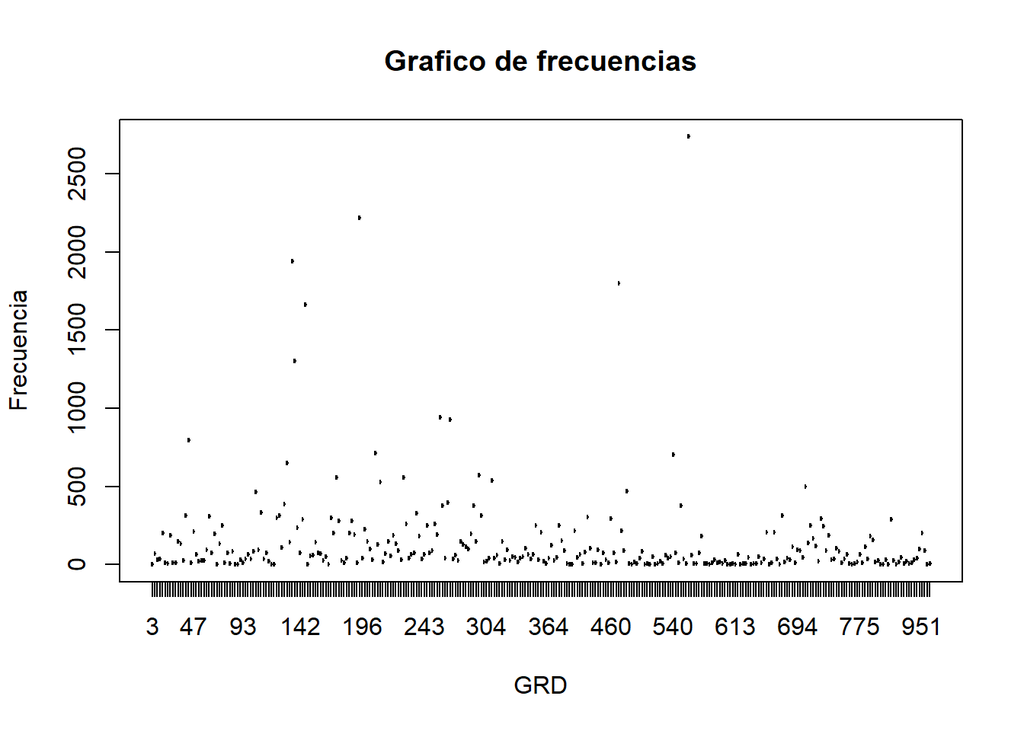

```r
plot(frecuencias[, 'GRD'], frecuencias[, 'Frecuencia'], xlab ="GRD", ylab ="Frecuencia", main ="Grafico de frecuencias")
```

```r
frecuentes <- frecuencias[ which(frecuencias[, 'Frecuencia'] >= 200), ]

(sum(frecuentes[, 'Frecuencia'])*100)/nrow(patologia_limpio)
```

```
## [1] 72.2158
```

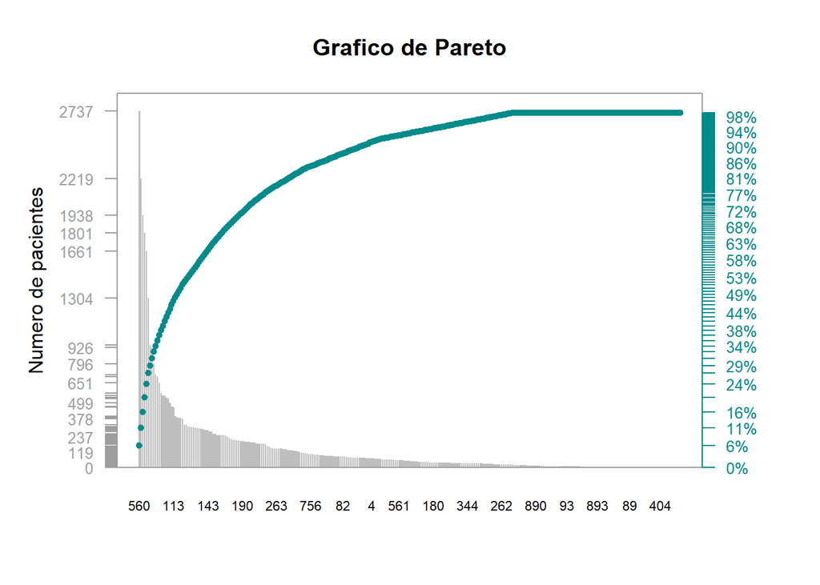

```r
# Ordeno y añado la frecuencia acumulada al dataframe frecuencias
frecuencias <- arrange(frecuencias, desc(Frecuencia)) %>%
        mutate(
                cumsum = cumsum(Frecuencia),
                freq = round(Frecuencia / sum(Frecuencia), 3),
                cum_freq = cumsum(freq)
               )

# Código para generar el gráfico de Pareto

# Guardo los parámetros
def_par <- par()

# Márgines
par(mar=c(5,5,4,5))

## Histograma, pc tendrá los valores del eje x
pc = barplot(frecuencias$Frecuencia,
             width = 1, space = 0.2, border = NA, axes = F,
             ylim = c(0, 1.05 * max(frecuencias$Frecuencia, na.rm = T)),
             ylab = "Numero de pacientes" , cex.names = 0.7,
             names.arg = frecuencias$GRD,
             main = "Grafico de Pareto")

## anotate left axis
axis(side = 2, at = c(0, frecuencias$Frecuencia), las = 1, col.axis = "grey62", col = "grey62", tick = T, cex.axis = 0.8)

## frame plot
box( col = "grey62")

## Líneas de las frecuencias acumuladas
px <- frecuencias$cum_freq * max(frecuencias$Frecuencia, na.rm = T)
lines(pc, px, type = "b", cex = 0.7, pch = 19, col="cyan4")

## Annotate Right Axis
axis(side = 4, at = c(0, px), labels = paste(c(0, round(frecuencias$cum_freq * 100)) ,"%",sep=""),
     las = 1, col.axis = "grey62", col = "cyan4", cex.axis = 0.8, col.axis = "cyan4")
```

```r
## restoring default paramenter
#par(def_par)

frecuentes <- frecuencias[1:81, ]
```

```r
# agrupo todos los pacientes que han tenido los GRD más frecuentes, mostrando el DCO.

diag_frecuentes <- merge(frecuentes, patologia_limpio, by = "GRD", all = FALSE)
dim(diag_frecuentes) # los pacientes analizados son 35285
```

```
## [1] 35285    13
```

```r
head(diag_frecuentes)
```

```
##   GRD Frecuencia cumsum  freq cum_freq    DCO Gender Edad   Fec_Serv
## 1 113        466  20573 0.011    0.468 J03.90      F   39 2016-04-26
## 2 113        466  20573 0.011    0.468 J09.X2      F   46 2016-02-20
## 3 113        466  20573 0.011    0.468  J06.9      F   76 2016-12-16
## 4 113        466  20573 0.011    0.468 J09.X2      F   59 2016-12-27
## 5 113        466  20573 0.011    0.468  J06.9      F   72 2017-01-04
## 6 113        466  20573 0.011    0.468 J09.X2      M   88 2017-11-02
##   Severidad Cdm                               Descripcion_GRD
## 1         1   3 INFECCIONES DE VÃ\215AS RESPIRATORIAS SUPERIORES
## 2         3   3 INFECCIONES DE VÃ\215AS RESPIRATORIAS SUPERIORES
## 3         2   3 INFECCIONES DE VÃ\215AS RESPIRATORIAS SUPERIORES
## 4         3   3 INFECCIONES DE VÃ\215AS RESPIRATORIAS SUPERIORES
## 5         1   3 INFECCIONES DE VÃ\215AS RESPIRATORIAS SUPERIORES
## 6         3   3 INFECCIONES DE VÃ\215AS RESPIRATORIAS SUPERIORES
##                                                                                 Descripcion_DCO
## 1                                                            Amigdalitis aguda, no especificada
## 2 Gripe debida a virus de la nueva gripe A identificado con otras manifestaciones respiratorias
## 3               InfecciÃ³n respiratoria aguda del tracto respiratorio superior, no especificada
## 4 Gripe debida a virus de la nueva gripe A identificado con otras manifestaciones respiratorias
## 5               InfecciÃ³n respiratoria aguda del tracto respiratorio superior, no especificada
## 6 Gripe debida a virus de la nueva gripe A identificado con otras manifestaciones respiratorias
```

Los pacientes analizados son 35285. Los CDM son 18, 81 GRD y 2190 DCO. Creo tablas de frecuencias para cada variable cómo edad, género, periodo temporal.

```r
# Agrupo los valores y calculo la frecuencia absoluta
tablaedad <- as.data.frame(table(edad = factor(cut(diag_frecuentes$Edad, breaks = c(0, 6, 12, 19, 27, 60, 108), labels = c("primera infancia 0-5", "infancia 6-11", "adolescencia 12-18","juventud 19-26", "adultez 27-59", "vejez 60 y mas"), right = FALSE))))


#labels = c("primera infancia 0-5", "infancia", "adolesciencia","juventud", "adultez", "vejez") ,
# Muestro la tabla de contingencia con la frecuencia absoluta de cada valor de la variable "edad"
# La moda es el valor con mayor frecuencia absoluta

tablaedad
```

```
##                   edad  Freq
## 1 primera infancia 0-5   968
## 2        infancia 6-11   233
## 3   adolescencia 12-18   409
## 4       juventud 19-26  1306
## 5        adultez 27-59  9413
## 6       vejez 60 y mas 22956
```

```r
#Muestro la tabla de frecuencias completa redondeando las frecuencias relativas a 3 decimales
transform(tablaedad,
          FreqAc = cumsum(Freq),
          Rel = round(prop.table(Freq), 3),
          RelAc = round(cumsum(prop.table(Freq)),3))
```

```
##                   edad  Freq FreqAc   Rel RelAc
## 1 primera infancia 0-5   968    968 0.027 0.027
## 2        infancia 6-11   233   1201 0.007 0.034
## 3   adolescencia 12-18   409   1610 0.012 0.046
## 4       juventud 19-26  1306   2916 0.037 0.083
## 5        adultez 27-59  9413  12329 0.267 0.349
## 6       vejez 60 y mas 22956  35285 0.651 1.000
```